# Final Project Proctical Machine Learning

danish

2022-05-07

# Overview

This is the final report for Coursera’s Practical Machine Learning course, as part of the Data Science Specialization track offered by John Hopkins.

# Background

Using devices such as Jawbone Up, Nike FuelBand, and Fitbit it is now possible to collect a large amount of data about personal activity relatively inexpensively. These type of devices are part of the quantified self movement - a group of enthusiasts who take measurements about themselves regularly to improve their health, to find patterns in their behavior, or because they are tech geeks. One thing that people regularly do is quantify how much of a particular activity they do, but they rarely quantify how well they do it. In this project, your goal will be to use data from accelerometers on the belt, forearm, arm, and dumbell of 6 participants. They were asked to perform barbell lifts correctly and incorrectly in 5 different ways. More information is available from the website here: (http://groupware.les.inf.puc-rio.br/har) (see the section on the Weight Lifting Exercise Dataset).

The training data for this project are available here:

https://d396qusza40orc.cloudfront.net/predmachlearn/pml-training.csv

The test data are available here:

https://d396qusza40orc.cloudfront.net/predmachlearn/pml-testing.csv

The data for this project come from this source: http://web.archive.org/web/20161224072740/http:/groupware.les.inf.puc-rio.br/har. If you use the document you create for this class for any purpose please cite them as they have been very generous in allowing their data to be used for this kind of assignment.

# Loading Data and Libraries

Loading all the libraries and the data

```r
library(readr)
library(lattice)
library(ggplot2)
library(caret)
library(kernlab)
library(rattle)
library(corrplot)
set.seed(1234)
```

```r
traincsv <- read_csv("~/Downloads/pml-training.csv")
testcsv <- read_csv("~/Downloads/pml-testing.csv")
dim(traincsv)
```

```
## [1] 19622   160
```

```r
dim(testcsv)
```

```
## [1]  20 160
```

We see that there are 160 variables and 19622 observations in the training set, while 20 for the test set.

# Cleaning the Data

Removing unnecessary variables. Starting with N/A variables.

```r
traincsv <- traincsv[,colMeans(is.na(traincsv)) < .9] #removing mostly na columns
traincsv <- traincsv[,-c(1:7)] #removing metadata which is irrelevant to the outcome
```

Now that we have finished removing the unnecessary variables, we can now split the training set into a **validation** and sub **training** set. The testing set “testcsv” will be left alone, and used for the final quiz test cases.

```r
inTrain <- createDataPartition(y=traincsv$classe, p=0.7, list=F)
train <- traincsv[inTrain,]
valid <- traincsv[-inTrain,]
```

# Creating and Testing the Models

Set up control for training to use 3-fold cross validation.

```r
control <- trainControl(method="cv", number=3, verboseIter=F)
```

## Decision Tree

**Model:**

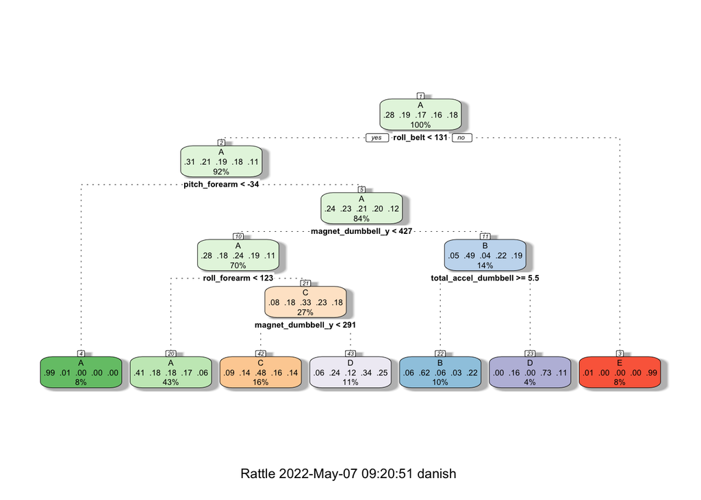

```r
mod_trees <- train(classe~., data=train, method="rpart", trControl = control, tuneLength = 5)
fancyRpartPlot(mod_trees$finalModel)
```

**Prediction:**

```r
pred_trees <- predict(mod_trees, valid)
cmtrees <- confusionMatrix(pred_trees, factor(valid$classe))
cmtrees
```

```
## Confusion Matrix and Statistics
##
##           Reference
## Prediction    A    B    C    D    E
##          A 1526  462  485  431  150
##          B   35  385   47   17  148
##          C   80  111  424  117  129
##          D   29  181   70  399  164
##          E    4    0    0    0  491
##
## Overall Statistics
##
##                Accuracy : 0.548
##                  95% CI : (0.5352, 0.5608)
##     No Information Rate : 0.2845
##     P-Value [Acc > NIR] : < 2.2e-16
##
##                   Kappa : 0.4108
##
##  Mcnemar's Test P-Value : < 2.2e-16
##
## Statistics by Class:
##
##                      Class: A Class: B Class: C Class: D Class: E
## Sensitivity            0.9116  0.33802  0.41326   0.4139  0.45379
## Specificity            0.6371  0.94796  0.91006   0.9098  0.99917
## Pos Pred Value         0.4997  0.60918  0.49245   0.4733  0.99192
## Neg Pred Value         0.9477  0.85646  0.88018   0.8879  0.89035
## Prevalence             0.2845  0.19354  0.17434   0.1638  0.18386
## Detection Rate         0.2593  0.06542  0.07205   0.0678  0.08343
## Detection Prevalence   0.5189  0.10739  0.14630   0.1432  0.08411
## Balanced Accuracy      0.7744  0.64299  0.66166   0.6618  0.72648
```

## Gradient Boosted Trees

```r
mod_gbm <- train(classe~., data=train, method="gbm", trControl = control, tuneLength = 5, verbose = F)
pred_gbm <- predict(mod_gbm, valid)
cmgbm <- confusionMatrix(pred_gbm, factor(valid$classe))
cmgbm
```

```
## Confusion Matrix and Statistics
##
##           Reference
## Prediction    A    B    C    D    E
##          A 1669   14    0    0    0
##          B    3 1122    8    0    2
##          C    2    3 1017    7    0
##          D    0    0    1  955    2
##          E    0    0    0    2 1078
##
## Overall Statistics
##
##                Accuracy : 0.9925
##                  95% CI : (0.99, 0.9946)
##     No Information Rate : 0.2845
##     P-Value [Acc > NIR] : < 2.2e-16
##
##                   Kappa : 0.9905
##
##  Mcnemar's Test P-Value : NA
##
## Statistics by Class:
##
##                      Class: A Class: B Class: C Class: D Class: E
## Sensitivity            0.9970   0.9851   0.9912   0.9907   0.9963
## Specificity            0.9967   0.9973   0.9975   0.9994   0.9996
## Pos Pred Value         0.9917   0.9885   0.9883   0.9969   0.9981
## Neg Pred Value         0.9988   0.9964   0.9981   0.9982   0.9992
## Prevalence             0.2845   0.1935   0.1743   0.1638   0.1839
## Detection Rate         0.2836   0.1907   0.1728   0.1623   0.1832
## Detection Prevalence   0.2860   0.1929   0.1749   0.1628   0.1835
## Balanced Accuracy      0.9968   0.9912   0.9944   0.9950   0.9979
```

## Support Vector Machine

```r
mod_svm <- train(classe~., data=train, method="svmLinear", trControl = control, tuneLength = 5, verbose = F)
pred_svm <- predict(mod_svm, valid)
cmsvm <- confusionMatrix(pred_svm, factor(valid$classe))
cmsvm
```

```
## Confusion Matrix and Statistics
##
##           Reference
## Prediction    A    B    C    D    E
##          A 1534  155   84   61   59
##          B   26  797   99   41  151
##          C   47   85  792  115   73
##          D   61   18   34  705   55
##          E    6   84   17   42  744
##
## Overall Statistics
##
##                Accuracy : 0.7769
##                  95% CI : (0.766, 0.7875)
##     No Information Rate : 0.2845
##     P-Value [Acc > NIR] : < 2.2e-16
##
##                   Kappa : 0.7164
##
##  Mcnemar's Test P-Value : < 2.2e-16
##
## Statistics by Class:
##
##                      Class: A Class: B Class: C Class: D Class: E
## Sensitivity            0.9164   0.6997   0.7719   0.7313   0.6876
## Specificity            0.9147   0.9332   0.9341   0.9659   0.9690
## Pos Pred Value         0.8104   0.7154   0.7122   0.8076   0.8331
## Neg Pred Value         0.9649   0.9283   0.9510   0.9483   0.9323
## Prevalence             0.2845   0.1935   0.1743   0.1638   0.1839
## Detection Rate         0.2607   0.1354   0.1346   0.1198   0.1264
## Detection Prevalence   0.3217   0.1893   0.1890   0.1483   0.1517
## Balanced Accuracy      0.9156   0.8165   0.8530   0.8486   0.8283
```

## Results (Accuracy & Out of Sample Error)

```
##      accuracy oos_error
## Tree    0.548     0.452
## GBM     0.993     0.007
## SVM     0.777     0.223
```

**The best model is the Gradient Boosted model, with 0.9925234 accuracy and 0.0074766 out of sample error rate. We find that to be a sufficient enough model to use for our test sets.**

# Predictions on Test Set

```r
pred <- predict(mod_gbm, testcsv)
print(pred)
```

```
##  [1] B A B A A E D B A A B C B A E E A B B B
## Levels: A B C D E
```

# Appendix

Github Repo: [Github](https://github.com/Decoder3818/Final-Project-Practical-Machine-Learning)

correlation matrix of variables in training set

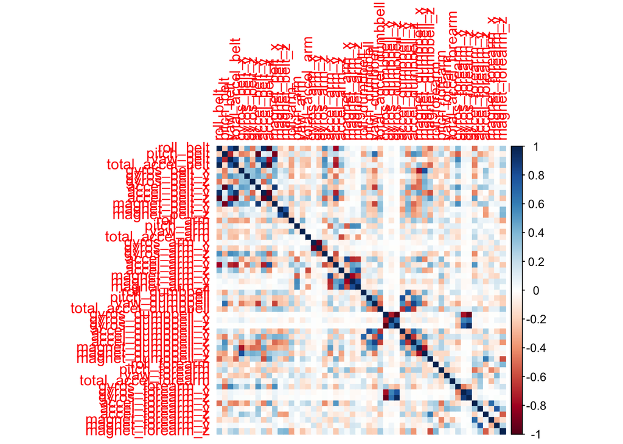

```r
corrPlot <- cor(train[, -length(names(train))])
corrplot(corrPlot, method="color")
```

Plotting the models

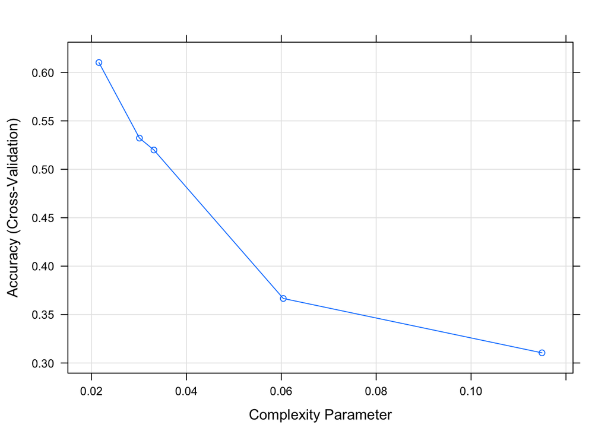

```r
plot(mod_trees)
```

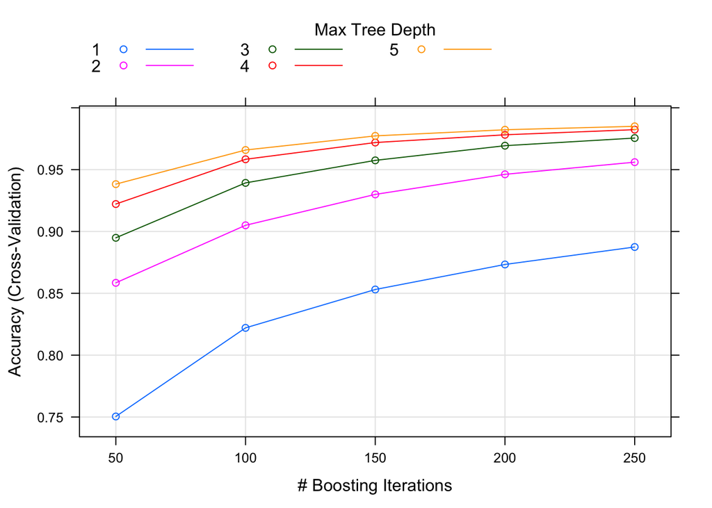

```r
plot(mod_gbm)
```